# Exp4: 基于K-近邻的车牌号识别

### 5.4 加权对KNN的影响

```python
from sklearn.neighbors import KNeighborsClassifier
accs3 = []
print("Weight = 1 / distance")
for kvalue in list_k:
    tree3 = KNeighborsClassifier(n_neighbors = kvalue, weights ='distance', algorithm = 'kd_tree', leaf_size = 65)
    tree3.fit(train_x, train_y)
    pred = tree3.predict(test_x)
    a = acc(pred, test_y)
    print("k = ", kvalue, "\t Accuracy: ", a)
    accs3.append(a)
```

```
Weight = 1 / distance
k =  1 	 Accuracy:  0.7168274383708467
k =  2 	 Accuracy:  0.7168274383708467
k =  3 	 Accuracy:  0.7103965702036441
k =  4 	 Accuracy:  0.7078242229367632
k =  5 	 Accuracy:  0.7016077170418007
k =  6 	 Accuracy:  0.6992497320471597
k =  7 	 Accuracy:  0.6992497320471597
k =  9 	 Accuracy:  0.6949624866023579
k =  11 	 Accuracy:  0.6930332261521972
k =  13 	 Accuracy:  0.6881028938906752
k =  15 	 Accuracy:  0.6821007502679528
k =  17 	 Accuracy:  0.6769560557341908
k =  19 	 Accuracy:  0.6718113612004287
k =  25 	 Accuracy:  0.6514469453376206
k =  31 	 Accuracy:  0.6439442658092176
k =  41 	 Accuracy:  0.6272240085744909
k =  51 	 Accuracy:  0.6188638799571275
```

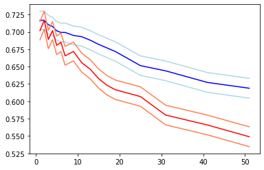

```python
error3 = []
accs3 = np.array(accs3)
for i in accs:
    err = 1.96 * np.sqrt(i*(1-i) / 4665) #95%置信区间的error
    error3.append(err)

error3 = np.array(error3)
accupper3 = accs3 + error3
acclower3 = accs3 - error3
plt.plot(list_k,accs3, color = 'blue', label = '加权')
plt.plot(list_k,accupper3, color = 'lightblue')
plt.plot(list_k,acclower3, color = 'lightblue' )
plt.plot(list_k,accs, color = 'red', label = '平权')
plt.plot(list_k,accupper,color = 'coral')
plt.plot(list_k,acclower, color = 'coral')
```

距离加权后，准确率总体提高了。且随着k值的增加，准确率下降趋势放缓，这说明距离加权后，越远的点对最终判断的影响越小。

思考：距离加权，改变核宽度，会带来什么影响呢？

```python
#传入distance array, 核宽度（默认为1/16 * 256 = 16），返回weight array
from copy import deepcopy
from math import exp

def kweight(dis, k = 16):
    weights = deepcopy(dis)
    for i, dist in enumerate(dis):
        weights[i] = exp(-dist*dist/(k*k))
    return weights

def predict3_(dis, indices, kk):
    pred = []
    for i, indice in enumerate(indices):
        p_labels = train_y[indice]
        w = kweight(dis[i], kk)
        uniq = list(set(p_labels))
        ww = []
        for label in uniq:
            wcount = 0
            for i, p in enumerate(p_labels):
                if p == label: wcount += w[i]
            ww.append(wcount)
        p = uniq[np.argmax(ww)]
        pred.append(p)

    return pred
```

```python
weightk = [1, 2, 4, 8, 16, 32, 64, 128, 256]
tree = KDTree(train_x, leaf_size = 65)
print("KDTree has been trained.")
dist, ind = tree.query(test_x, k=3)
print("3 neighbours for each test sample have been found.")
```

[output not shown]

```python
accs5 = []
for kk in weightk:
    pred = predict3_(dist, ind, kk)
    a = acc(pred, test_y)
    print("k = ", kk , "\t Accuracy: ", a)
    accs5.append(a)
```

```
k =  1 	 Accuracy:  0.742336548767417
k =  2 	 Accuracy:  0.742336548767417
k =  4 	 Accuracy:  0.742336548767417
k =  8 	 Accuracy:  0.742336548767417
k =  16 	 Accuracy:  0.742336548767417
k =  32 	 Accuracy:  0.742550911039657
k =  64 	 Accuracy:  0.7247588424437299
k =  128 	 Accuracy:  0.717470525187567
k =  256 	 Accuracy:  0.7187566988210075
```

```python
tree = KDTree(train_x, leaf_size = 65)
print("KDTree has been trained.")
dist, ind = tree.query(test_x, k=30)
print("30 neighbours for each test sample have been found.")
```

```
KDTree has been trained.
30 neighbours for each test sample have been found.
```

```python
accs6 = []
for kk in weightk:
    pred = predict3_(dist, ind, kk)
    a = acc(pred, test_y)
    print("k = ", kk , "\t Accuracy: ", a)
    accs6.append(a)
```

```
k =  1 	 Accuracy:  0.5560557341907825
k =  2 	 Accuracy:  0.5560557341907825
k =  4 	 Accuracy:  0.5560557341907825
k =  8 	 Accuracy:  0.5560557341907825
k =  16 	 Accuracy:  0.5560557341907825
k =  32 	 Accuracy:  0.5618435155412648
k =  64 	 Accuracy:  0.685101822079314
k =  128 	 Accuracy:  0.7176848874598071
k =  256 	 Accuracy:  0.7181136120042872
```

有趣的现象，选择3个邻居时，随着核宽度的增加，Accuracy可能出现了下降趋势；但是选择30个邻居时，随着核宽度的增加，accuracy逐渐增加。

思考：这是为什么呢？？

### 5.5 训练集大小对测试结果的影响

```python
#每个分类，最多读取多少个样本
nEach = [1, 2, 3, 4, 5, 6, 7, 8, 9, 10, 15, 20, 30, 50, 100, 150, 200, 300]

accs4 = []

def predict2_(indices):
    pred = []
    for indice in indices:
        p_labels = train_y2[indice] #取出所有predict的label
        p = mod(p_labels) #取出众数
        pred.append(p)
    return pred

for neach in nEach:
    path = r"data/train"
    folders= os.listdir(path)
    train_images2 = []
    train_labels2 = []
    for folder in folders:
        j = 0
        subpath = path + '\\'+ folder
        files = os.listdir(subpath)
        for file in files:
            j+=1
            if j <= neach:
                position = subpath + '\\' + file
                with Image.open(position) as img:    #打开文件
                    pixels = np.array(img)
                    train_images2.append(pixels)
                    train_labels2.append(folder)

    train_x2 = np.array(train_images2).reshape(-1, 400)
    train_y2 = np.array(train_labels2)

    tree = KDTree(train_x2, leaf_size = 65)
    dist, ind = tree.query(test_x, k=3)
    pred = predict2_(ind)
    a = acc(pred, test_y)
    print("n = ", neach, "\t Accuracy: ", a)
    accs4.append(a)
```

```
n =  1 	 Accuracy:  0.07717041800643087
n =  2 	 Accuracy:  0.2898177920685959
n =  3 	 Accuracy:  0.362486602357985
n =  4 	 Accuracy:  0.3969989281886388
n =  5 	 Accuracy:  0.4398713826366559
n =  6 	 Accuracy:  0.45209003215434085
n =  7 	 Accuracy:  0.46966773847802784
n =  8 	 Accuracy:  0.4739549839228296
n =  9 	 Accuracy:  0.4979635584137192
n =  10 	 Accuracy:  0.5018220793140408
n =  15 	 Accuracy:  0.5393354769560558
n =  20 	 Accuracy:  0.5573419078242229
n =  30 	 Accuracy:  0.5933547695605573
n =  50 	 Accuracy:  0.632583065380493
n =  100 	 Accuracy:  0.6531618435155413
n =  150 	 Accuracy:  0.6508038585209003
n =  200 	 Accuracy:  0.6790996784565917
n =  300 	 Accuracy:  0.7061093247588425
```

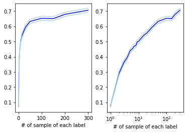

```python
accs4 = np.array(accs4)
error4 = []
for i in accs4:
    err = 1.96 * np.sqrt(i*(1-i) / 4665) #95%置信区间的error
    error4.append(err)

error4 = np.array(error4)
accupper4 = accs4 + error4
acclower4 = accs4 - error4

plt.subplot(1, 2, 1)
plt.plot(nEach,accs4, color = 'blue')
plt.plot(nEach,accupper4, color = 'lightblue')
plt.plot(nEach,acclower4, color = 'lightblue' )
plt.xlabel('# of sample of each label')

plt.subplot(1, 2, 2)
plt.plot(nEach,accs4, color = 'blue')
plt.plot(nEach,accupper4, color = 'lightblue')
plt.plot(nEach,acclower4, color = 'lightblue' )
plt.xlabel('# of sample of each label')
plt.xscale('log')
```

随着训练集样本数量的增加，K=3的KNN准确率逐渐增加。当n<=5的时候，提升尤其明显。后期，随着n的增加，accuracy甚至可能下降，这可能是因为噪声的影响。 总体上升的趋势说明，更大的有效训练集有利于提高模型的预测结果。

## 六、总结

在这次的实训案例中，学习实践了KNN模型的搭建，体会了k值、距离度量方式、加权方式、训练集大小对KNN模型效果的影响。对KNN有了更深入的了解，但同时也带来了很多疑惑和深入探究的可能。时间有限，很多地方没有再深入讨论。